# fig6_abcd and sfig14 and efig8ab: ChIP-nexus profiles and validation across CRISPR site: chr10:85,539,626-85,539,777

Melanie (1028-02098-001-001)

December 01, 2020

# Introduction

We seek to compare the differences between the BPNet predictions of mutating Sox2 and Nanog motifs at the site below versus the CRISPR results.

WT mm10: chr10:85,539,626-85,539,777  
CCTCTGGGCCTTTGTTCCTCCACTGACTGTCCTCCAACAACAATTATAATGATAATAGCAGCTGCCATTATTGAGCTATTTATAGAGAGCAAGCTGTATTTCACTCATTTAATCTTCCAGCAGCAAGGCAACTGATGGCTGTGCTGGAAGTT

mESC-R1_Nanog_mut_1 :we used 3 different clones: B07, B09 and F10 CCTCTGGGCCTTTGTTCCTCCACTGACTGTCCTCCAACAACAATTATAATGATAATAGCAGCTGCCATTATTGAGCTATTTATAGAGAGCAAGCTGTATTTCACTCATTTAATCTTCCAGCAGCAAGGCAACGGCTGGCTGTGCTGGAAGTT

mESC-R1_Sox2_mut_1 :we used 3 different clones: B07, B11 and C10 CCTCTGGGCCTAGGTTCCTCCACTGACTGTCCTCCAACAACAATTATAATGATAATAGCAGCTGCCATTATTGAGCTATTTATAGAGAGCAAGCTGTATTTCACTCATTTAATCTTCCAGCAGCAAGGCAACTGATGGCTGTGCTGGAAGTT

A second set of samples were run in the Nova-seq in order to get a set of high-quality, same time frame, same antibody samples for both the mutants and the WT. Here, we look at the results, plot them, and validate replicate consistency.

# Computational Setup

```r
#Standard packages
library(rtracklayer) ; library(GenomicRanges); library(magrittr) ; library(Biostrings)
library(ggplot2) ; library(reshape2); library(Rsamtools); library(data.table); library(dplyr)
library(BSgenome.Mmusculus.UCSC.mm10); library(viridis)

#KNITR Options
setwd("/n/projects/mw2098/publications/2019_bpnet/")
options(knitr.figure_dir="figures/18-fig6abcd_sfig14_efig8ab-crispr-sox2-nanog/", width=16, height=12)

#Lab sources
source("/n/projects/mw2098/shared_code/rscripts/granges_common.r")
source("/n/projects/mw2098/shared_code/rscripts/metapeak_common.r")
source("/n/projects/mw2098/shared_code/rscripts/knitr_common.r")
source("/n/projects/mw2098/shared_code/rscripts/caching.r")
source("/n/projects/mw2098/shared_code/custom/metapeak_functions.R")
source("/n/projects/mw2098/shared_code/rscripts/multiplot.R")

#Special sources
library(readr)
library(stringr)
library(signal)
library(grid)
library(gridExtra)
library(readxl)
library(DescTools)
library(gtable)
library(ggpubr)
# library(ggrastr) # devtools::install_github('VPetukhov/ggrastr')
library(patchwork)
```

# Define annotations

Here, define paths for coordinates and regions to validate across.

```r
instances.path<-"data/tsv/dfi_subset.tsv" #all CWM-mapped instances from BPNet/TF-MoDISco run
peaks.path<-"data/bed/peaks.bed" #all peaks from OSKN that BPNet was trained/tested/validated on
enhancers.path<-"data/xlsx/enhancer_regions_formatted_v3.xlsx" #curated set of enhancers in mESCs
```

# Define bws

We will define BW sets across Sox2 CRISPR lines and Nanog CRISPR lines.

## CRISPR ChIP-nexus (actual)

Normalized = reads per million sample normalization Naming convention: `mesc_[1]_[2]_nexus_[3]_dedup_combined_normalized_[4]` where…

1. Mutant state: Whether the sample was a Sox2 mutant, Nanog mutant, or WT.
2. TF: Which TF the ChIP-nexus was conducted over.
3. Set number: Whether the samples came from the original set of BPNet ChIP-nexus samples (set1) or the CRISPR set of ChIP-nexus samples (set2). In this .Rmd, all samples are from set2 that used the Nanog Abcam antibody and the Sox2 Active Motif antibody.
4. Strand: The strand of the ChIP-nexus sample

```r
# Combined based on CRISPR and ChIP
crispr_chip_set2.bw.list<-list(
  sox2mut_sox2 = list(
    pos = "data/bw/nexus_crispr/combined_by_crispr_chip_set/normalized/mesc_sox2crispr1_sox2_nexus_set2_dedup_combined_normalized_positive.bw",
    neg = "data/bw/nexus_crispr/combined_by_crispr_chip_set/normalized/mesc_sox2crispr1_sox2_nexus_set2_dedup_combined_normalized_negative.bw"),
  sox2mut_nanog = list(
    pos = "data/bw/nexus_crispr/combined_by_crispr_chip_set/normalized/mesc_sox2crispr1_nanog_nexus_set2_dedup_combined_normalized_positive.bw",
    neg = "data/bw/nexus_crispr/combined_by_crispr_chip_set/normalized/mesc_sox2crispr1_nanog_nexus_set2_dedup_combined_normalized_negative.bw"),
  nanogmut_sox2 = list(
    pos = "data/bw/nexus_crispr/combined_by_crispr_chip_set/normalized/mesc_nanogcrispr1_sox2_nexus_set2_dedup_combined_normalized_positive.bw",
    neg = "data/bw/nexus_crispr/combined_by_crispr_chip_set/normalized/mesc_nanogcrispr1_sox2_nexus_set2_dedup_combined_normalized_negative.bw"),
  nanogmut_nanog = list(
    pos = "data/bw/nexus_crispr/combined_by_crispr_chip_set/normalized/mesc_nanogcrispr1_nanog_nexus_set2_dedup_combined_normalized_positive.bw",
    neg = "data/bw/nexus_crispr/combined_by_crispr_chip_set/normalized/mesc_nanogcrispr1_nanog_nexus_set2_dedup_combined_normalized_negative.bw"),
  wt_sox2 = list(
    pos = "data/bw/nexus_crispr/combined_by_crispr_chip_set/normalized/mesc_wt_sox2_nexus_set2_dedup_combined_normalized_positive.bw",
    neg = "data/bw/nexus_crispr/combined_by_crispr_chip_set/normalized/mesc_wt_sox2_nexus_set2_dedup_combined_normalized_negative.bw"),
  wt_nanog = list(
    pos = "data/bw/nexus_crispr/combined_by_crispr_chip_set/normalized/mesc_wt_nanog_nexus_set2_dedup_combined_normalized_positive.bw",
    neg = "data/bw/nexus_crispr/combined_by_crispr_chip_set/normalized/mesc_wt_nanog_nexus_set2_dedup_combined_normalized_negative.bw"))
```

### CRISPR ChIP-nexus (actual and divided by replicate)

Normalized = reads per million sample normalization Naming convention: `mesc_[1]_[2]_nexus_[3]_[4]_dedup_combined_normalized_[5]` where…

1. Mutant state: Whether the sample was a Sox2 mutant, Nanog mutant, or WT.
2. TF: Which TF the ChIP-nexus was conducted over.
3. Replicate/Clone: Which technical replicate/biological clone each sample originated from.
4. Set number: Whether the samples came from the original set of BPNet ChIP-nexus samples (set1) or the CRISPR set of ChIP-nexus samples (set2). In this .Rmd, all samples are from set2.
5. Strand: The strand of the ChIP-nexus sample

```r
wt.nanog.bw.list<-list(rep1 = list(pos = "data/bw/nexus_crispr/combined_by_crispr_chip_set_rep/normalized/mesc_wt_nanog_nexus_10_set2_dedup_normalized_positive.bw",
                                   neg = "data/bw/nexus_crispr/combined_by_crispr_chip_set_rep/normalized/mesc_wt_nanog_nexus_10_set2_dedup_normalized_negative.bw"),
                       rep2 = list(pos = "data/bw/nexus_crispr/combined_by_crispr_chip_set_rep/normalized/mesc_wt_nanog_nexus_11_set2_dedup_normalized_positive.bw",
                                   neg = "data/bw/nexus_crispr/combined_by_crispr_chip_set_rep/normalized/mesc_wt_nanog_nexus_11_set2_dedup_normalized_negative.bw"),
                       rep3 = list(pos = "data/bw/nexus_crispr/combined_by_crispr_chip_set_rep/normalized/mesc_wt_nanog_nexus_12_set2_dedup_normalized_positive.bw",
                                   neg = "data/bw/nexus_crispr/combined_by_crispr_chip_set_rep/normalized/mesc_wt_nanog_nexus_12_set2_dedup_normalized_negative.bw"))

wt.sox2.bw.list<- list(rep1 = list(pos = "data/bw/nexus_crispr/combined_by_crispr_chip_set_rep/normalized/mesc_wt_sox2_nexus_11_set2_dedup_normalized_positive.bw",
                                   neg = "data/bw/nexus_crispr/combined_by_crispr_chip_set_rep/normalized/mesc_wt_sox2_nexus_11_set2_dedup_normalized_negative.bw"),
                       rep2 = list(pos = "data/bw/nexus_crispr/combined_by_crispr_chip_set_rep/normalized/mesc_wt_sox2_nexus_12_set2_dedup_normalized_positive.bw",
                                   neg = "data/bw/nexus_crispr/combined_by_crispr_chip_set_rep/normalized/mesc_wt_sox2_nexus_12_set2_dedup_normalized_negative.bw"))

sox2_crispr1.sox2.bw.list<-list(B07 = list(pos = "data/bw/nexus_crispr/combined_by_crispr_chip_set_rep/mesc_sox2crispr1_sox2_nexus_b07_3_set2_dedup_positive.bw",
                                           neg = "data/bw/nexus_crispr/combined_by_crispr_chip_set_rep/mesc_sox2crispr1_sox2_nexus_b07_3_set2_dedup_negative.bw"),
                                B11 = list(pos = "data/bw/nexus_crispr/combined_by_crispr_chip_set_rep/mesc_sox2crispr1_sox2_nexus_b11_3_set2_dedup_positive.bw",
                                           neg = "data/bw/nexus_crispr/combined_by_crispr_chip_set_rep/mesc_sox2crispr1_sox2_nexus_b11_3_set2_dedup_negative.bw"),
                                C10 = list(pos = "data/bw/nexus_crispr/combined_by_crispr_chip_set_rep/mesc_sox2crispr1_sox2_nexus_c10_3_set2_dedup_positive.bw",
                                           neg = "data/bw/nexus_crispr/combined_by_crispr_chip_set_rep/mesc_sox2crispr1_sox2_nexus_c10_3_set2_dedup_negative.bw"))

sox2_crispr1.nanog.bw.list<-list(B07 = list(pos = "data/bw/nexus_crispr/combined_by_crispr_chip_set_rep/mesc_sox2crispr1_nanog_nexus_b07_4_set2_dedup_positive.bw",
                                            neg = "data/bw/nexus_crispr/combined_by_crispr_chip_set_rep/mesc_sox2crispr1_nanog_nexus_b07_4_set2_dedup_negative.bw"),
                                 B11 = list(pos = "data/bw/nexus_crispr/combined_by_crispr_chip_set_rep/mesc_sox2crispr1_nanog_nexus_b11_4_set2_dedup_positive.bw",
                                            neg = "data/bw/nexus_crispr/combined_by_crispr_chip_set_rep/mesc_sox2crispr1_nanog_nexus_b11_4_set2_dedup_negative.bw"),
                                 C10 = list(pos = "data/bw/nexus_crispr/combined_by_crispr_chip_set_rep/mesc_sox2crispr1_nanog_nexus_c10_4_set2_dedup_positive.bw",
                                            neg = "data/bw/nexus_crispr/combined_by_crispr_chip_set_rep/mesc_sox2crispr1_nanog_nexus_c10_4_set2_dedup_negative.bw"))

nanog_crispr1.sox2.bw.list<-list(B07 = list(pos = "data/bw/nexus_crispr/combined_by_crispr_chip_set_rep/mesc_nanogcrispr1_sox2_nexus_b07_1_set2_dedup_positive.bw",
                                            neg = "data/bw/nexus_crispr/combined_by_crispr_chip_set_rep/mesc_nanogcrispr1_sox2_nexus_b07_1_set2_dedup_negative.bw"),
                                 B09 = list(pos = "data/bw/nexus_crispr/combined_by_crispr_chip_set_rep/mesc_nanogcrispr1_sox2_nexus_b09_1_set2_dedup_positive.bw",
                                            neg = "data/bw/nexus_crispr/combined_by_crispr_chip_set_rep/mesc_nanogcrispr1_sox2_nexus_b09_1_set2_dedup_negative.bw"),
                                 F10 = list(pos = "data/bw/nexus_crispr/combined_by_crispr_chip_set_rep/mesc_nanogcrispr1_sox2_nexus_f10_1_set2_dedup_positive.bw",
                                            neg = "data/bw/nexus_crispr/combined_by_crispr_chip_set_rep/mesc_nanogcrispr1_sox2_nexus_f10_1_set2_dedup_negative.bw"))

nanog_crispr1.nanog.bw.list<-list(B07 = list(pos = "data/bw/nexus_crispr/combined_by_crispr_chip_set_rep/mesc_nanogcrispr1_nanog_nexus_b07_2_set2_dedup_positive.bw",
                                            neg = "data/bw/nexus_crispr/combined_by_crispr_chip_set_rep/mesc_nanogcrispr1_nanog_nexus_b07_2_set2_dedup_negative.bw"),
                                 B09 = list(pos = "data/bw/nexus_crispr/combined_by_crispr_chip_set_rep/mesc_nanogcrispr1_nanog_nexus_b09_2_set2_dedup_positive.bw",
                                            neg = "data/bw/nexus_crispr/combined_by_crispr_chip_set_rep/mesc_nanogcrispr1_nanog_nexus_b09_2_set2_dedup_negative.bw"),
                                 F10 = list(pos = "data/bw/nexus_crispr/combined_by_crispr_chip_set_rep/mesc_nanogcrispr1_nanog_nexus_f10_2_set2_dedup_positive.bw",
                                            neg = "data/bw/nexus_crispr/combined_by_crispr_chip_set_rep/mesc_nanogcrispr1_nanog_nexus_f10_2_set2_dedup_negative.bw"))
```

## BPNet ChIP-nexus (predicted)

Predicted BigWig files.

Naming convention: `[1]_[2]_[3]_preds` where…

1. Mutant state: Whether the sample was a Sox2 mutant, Nanog mutant, or WT.
2. TF: Which TF the ChIP-nexus was conducted over.
3. Strand: The strand of the ChIP-nexus sample.

```r
#Coverage only at the CRISPR site genomic loci.
bpnet.bw.list<-list(
  wt_nanog = list(
    pos = "data/bw/predictions_crispr/wt_Nanog_pos_preds.bw",
    neg = "data/bw/predictions_crispr/wt_Nanog_neg_preds.bw"),
  nanogmut_nanog = list(
    pos = "data/bw/predictions_crispr/nanog_mut_Nanog_pos_preds.bw",
    neg = "data/bw/predictions_crispr/nanog_mut_Nanog_neg_preds.bw"),
  sox2mut_nanog = list(
    pos = "data/bw/predictions_crispr/sox2_mut_Nanog_pos_preds.bw",
    neg = "data/bw/predictions_crispr/sox2_mut_Nanog_neg_preds.bw"),
  wt_sox2 = list(
    pos = "data/bw/predictions_crispr/wt_Sox2_pos_preds.bw",
    neg = "data/bw/predictions_crispr/wt_Sox2_neg_preds.bw"),
  nanogmut_sox2 = list(
    pos = "data/bw/predictions_crispr/nanog_mut_Sox2_pos_preds.bw",
    neg = "data/bw/predictions_crispr/nanog_mut_Sox2_neg_preds.bw"),
  sox2mut_sox2 = list(
    pos = "data/bw/predictions_crispr/sox2_mut_Sox2_pos_preds.bw",
    neg = "data/bw/predictions_crispr/sox2_mut_Sox2_neg_preds.bw"))

#Coverage across every peak.
bpnet.wt.bw.list<-list(
  wt_nanog = list(
    pos = "data/bw/predictions/Nanog.preds.pos.bw",
    neg = "data/bw/predictions/Nanog.preds.neg.bw"),
  wt_sox2 = list(
    pos = "data/bw/predictions/Sox2.preds.pos.bw",
    neg = "data/bw/predictions/Sox2.preds.neg.bw"))
```

# Define coordinates of interest

```r
#Define CRISPR sites
region<-GRanges(seqnames = "chr10", ranges = IRanges(start = 85539626, end = 85539777), strand = "+")
region_centered<-region %>% resize(1, "center")
width(region)
```

```
## [1] 152
```

```r
#Define motifs
motif_coordinates.gr<-read.table(instances.path, header = T, sep = "\t") %>%
  makeGRangesFromDataFrame(keep.extra.columns = T, starts.in.df.are.0based = T,
                           start.field = "pattern_start_abs", end.field = "pattern_end_abs", seqnames.field = "example_chrom") %>%
  subsetByOverlaps(., region, ignore.strand = T) %>% unique %>%  .[-c(3)]
motif_coordinates.gr$name<-c("Sox2", "Nanog")

export(motif_coordinates.gr, "data/bed/crispr_motif_coords.bed")
motif_coordinates.df<-motif_coordinates.gr %>%
  as.data.frame(stringsAsFactors = F)
```

# Get metapeaks

```r
get_obs_and_pred_profiles<-function(crisprsite.gr, crispr.list, bpnet.list,
                                    upstream = 150, downstream = 151){

  #Get actual ChIP-nexus signal from coordinates
  crispr.df<-mclapply(names(crispr.list), function(x){
    df<-exo_metapeak(gr = crisprsite.gr, sample = crispr.list[[x]],
                     upstream = upstream, downstream = downstream)
    df$type<-"CRISPR"
    df$condition<-x
    df$position<-df$tss_distance + start(crisprsite.gr) - 1
    df
  }, mc.cores = 4) %>% rbindlist

  #Get predicted ChIP-nexus signal from coordinates.
  bpnet.df<-mclapply(names(bpnet.list), function(x){
    df<-exo_metapeak(gr = crisprsite.gr, sample = bpnet.list[[x]],
                     upstream = upstream, downstream = downstream)
    df$type<-"BPNet"
    df$condition<-x
    df$position<-df$tss_distance + start(crisprsite.gr) - 1
    df
  }, mc.cores = 4) %>% rbindlist


  #Have two normalization strategies:
  #reads = obs is RPM, pred is exp(counts)*profile
  #norm_reads = obs is prob, pred is prob.
  crispr.df <- crispr.df %>%
    dplyr::group_by(type, condition) %>%
    dplyr::mutate(norm_reads = reads/sum(abs(reads)))
  bpnet.df <- bpnet.df %>%
    dplyr::group_by(type, condition) %>%
    dplyr::mutate(norm_reads = reads/sum(abs(reads)))
  signals.df<-rbind(crispr.df, bpnet.df)

  #Format DF
  signals.df$mut<-signals.df$condition %>%
    stringr::str_split(., "_") %>%
    lapply(., function(x) x[1]) %>% unlist
  signals.df$fac<-signals.df$condition %>%
    stringr::str_split(., "_") %>%
    lapply(., function(x) x[2]) %>% unlist

  signals.df$mut<-factor(signals.df$mut, levels = c("wt", "nanogmut", "sox2mut"),
                         labels = c("WT", "Nanog mutant", "Sox2 mutant"))
  signals.df$fac<-factor(signals.df$fac, levels = c("sox2", "nanog"),
                         labels = c("Sox2 ChIP-nexus", "Nanog ChIP-nexus"))
  signals.df$type<-factor(signals.df$type, levels = c("BPNet", "CRISPR"),
                          labels = c("BPNet predictions", "CRISPR signal"))

  signals.df$type_fac_id<-paste0(signals.df$type, ", ", signals.df$fac)

  return(signals.df)
}

crispr_chip_set2_comparison.df<-get_obs_and_pred_profiles(crisprsite.gr = region_centered,
                                                          crispr.list = crispr_chip_set2.bw.list,
                                                          bpnet.list = bpnet.bw.list)
```

# Plot obs vs predicted profiles

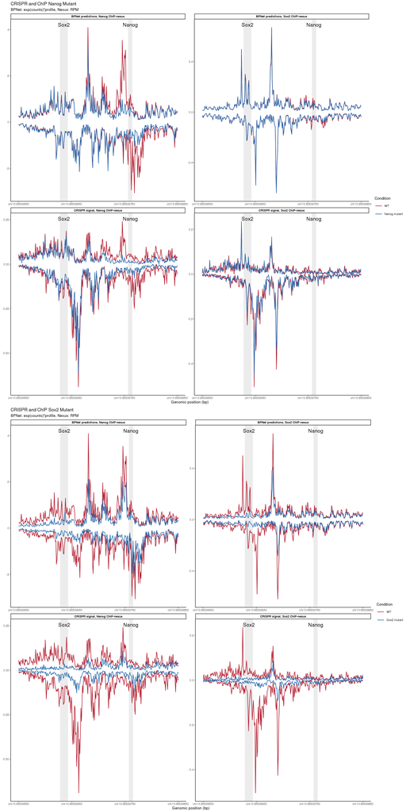

```r
get_obs_vs_pred_plots<-function(df, output_prefix, normalized = F){

  nanog_mut.plot<-ggplot(subset(df, mut != "Sox2 mutant"))+
    geom_rect(data = motif_coordinates.df, aes(xmin = start, xmax = end, ymin = -Inf, ymax = Inf), alpha = .5, fill = "gray85")+
    geom_text(data = motif_coordinates.df, aes(x = ((end-start)/2 + start), y = Inf, label = name), vjust = 2)

    if(normalized){nanog_mut.plot<-nanog_mut.plot +
      facet_wrap(~ type_fac_id, ncol = 2)+
      geom_line(aes(x=position, y=norm_reads, group = interaction(strand, mut), color = mut), position = "identity")}
    else{
      nanog_mut.plot<-nanog_mut.plot +
      facet_wrap(~ type_fac_id, scales = "free", ncol = 2)+
      geom_line(aes(x=position, y=reads, group = interaction(strand, mut), color = mut), position = "identity")
    }

    nanog_mut.plot<-nanog_mut.plot +
    scale_x_continuous(name = "Genomic position (bp)",
                       breaks = seq(min(df$position), max(df$position), 100),
                       labels = paste0("chr10:", seq(min(df$position), max(df$position), 100)))+
    scale_color_manual(values = c("#b2182b", "#2166ac"), name = "Condition")+
    ggtitle("CRISPR and ChIP Nanog Mutant",
            subtitle = if(normalized){"BPNet: Prob, Nexus: Prob"}else{"BPNet: exp(counts)*profile, Nexus: RPM"})+
    theme_classic(base_size = 8)+
    theme(strip.text = element_text(color = "black", face = "bold"), axis.text.x = element_text(), axis.title.y = element_blank())

  sox2_mut.plot<-ggplot(subset(df, mut != "Nanog mutant"))+
    geom_rect(data = motif_coordinates.df, aes(xmin = start, xmax = end, ymin = -Inf, ymax = Inf), alpha = .5, fill = "gray85")+
    geom_text(data = motif_coordinates.df, aes(x = ((end-start)/2 + start), y = Inf, label = name), vjust = 2)

    if(normalized){sox2_mut.plot<-sox2_mut.plot +
      facet_wrap(~ type_fac_id, ncol = 2)+
      geom_line(aes(x=position, y=norm_reads, group = interaction(strand, mut), color = mut), position = "identity")}
    else{sox2_mut.plot<-sox2_mut.plot +
      facet_wrap(~ type_fac_id, scales = "free", ncol = 2)+
      geom_line(aes(x=position, y=reads, group = interaction(strand, mut), color = mut), position = "identity")}

    sox2_mut.plot<-sox2_mut.plot +
    scale_x_continuous(name = "Genomic position (bp)",
                       breaks = seq(min(df$position), max(df$position), 100),
                       labels = paste0("chr10:", seq(min(df$position), max(df$position), 100)))+
    scale_color_manual(values = c("#b2182b", "#2166ac"), name = "Condition")+
    ggtitle("CRISPR and ChIP Sox2 Mutant",
            subtitle = if(normalized){"BPNet: Prob, Nexus: Prob"}else{"BPNet: exp(counts)*profile, Nexus: RPM"})+
    theme_classic(base_size = 8)+
    theme(strip.text = element_text(color = "black", face = "bold"), axis.text.x = element_text(), axis.title.y = element_blank())

  ggsave(paste0(output_prefix, ".pdf"),
         grid.arrange(grobs = list(nanog_mut.plot, sox2_mut.plot), ncol = 1),
         height = 12, width = 12)
  ggsave(paste0(output_prefix, ".png"),
         grid.arrange(grobs = list(nanog_mut.plot, sox2_mut.plot), ncol = 1),
         height = 12, width = 12)

  return(grid.arrange(grobs = list(nanog_mut.plot, sox2_mut.plot), ncol = 1))
}

#RPM and counts*(profile)
filler<-get_obs_vs_pred_plots(df = crispr_chip_set2_comparison.df,
                              output_prefix = "figures/18-fig6abcd_sfig14_efig8ab-crispr-sox2-nanog/fig6abcd-crispr-sox2-nanog")
```

# Validate using enhancer regions defined in SFig

Do the profiles from the different ChIP-nexus samples (mut vs WT) look the same at the enhancers in the SFigs of the manuscript?

## Define enhancers

```r
supp_enhancers.gr<-c(
  GRanges("chr17", IRanges(35503970, 35504125), name = "Oct4 distal enhancer"),
  GRanges("chr4", IRanges(55475545, 55475604), name = "Klf4 E2 enhancer"),
  GRanges("chr6", IRanges(122707394, 122707454), name = "Nanog enhancer"),
  GRanges("chr18", IRanges(84934461, 84934521), name = "Fbx15 enhancer"),
  GRanges("chr1", IRanges(136680205, 136680605), name = "Zpf281 enhancer"),
  GRanges("chr8", IRanges(89003541, 89003941), name = "Sall1 enhancer"))
seqlevels(supp_enhancers.gr)<-seqlevels(BSgenome.Mmusculus.UCSC.mm10)
seqinfo(supp_enhancers.gr)<-seqinfo(BSgenome.Mmusculus.UCSC.mm10)
```

## Get signals across each enhancer

Get the WT regions for ChIP-nexus and BPNet signal across each enhancer region.

```r
tracks.df<-mclapply(1:length(supp_enhancers.gr), function(x){
  track.df<-get_obs_and_pred_profiles(crisprsite.gr = supp_enhancers.gr[x] %>% #rep. enhancer site
                                                      resize(width = 1, "center"),
                                      crispr.list = crispr_chip_set2.bw.list,
                                      bpnet.list = bpnet.wt.bw.list, #get general predictions for later.
                                      upstream = 150, downstream = 151)
  track.df$name<-supp_enhancers.gr[x]$name
  track.df$chr<-supp_enhancers.gr[x] %>% seqnames() %>% .[1] %>% as.character
  return(track.df)
}, mc.cores = 6) %>% rbindlist
```

# Plot the enhancer signals

```r
mclapply(unique(tracks.df$name), function(x){
  tracks.plot.df<-tracks.df %>%
    dplyr::filter(name == x, type == "CRISPR signal") #Keep actual signal, remove predictions.
  tracks.plot.df$mut_fac_id<-paste0(tracks.plot.df$mut, ", ", tracks.plot.df$fac)
  tracks.plot.df$mut_fac_id<-factor(
    tracks.plot.df$mut_fac_id,
    levels = c("WT, Sox2 ChIP-nexus", "Sox2 mutant, Sox2 ChIP-nexus",
               "Nanog mutant, Sox2 ChIP-nexus",
               "WT, Nanog ChIP-nexus", "Sox2 mutant, Nanog ChIP-nexus",
               "Nanog mutant, Nanog ChIP-nexus"),
    labels = c("Condition: WT\nChIP: Sox2", "Condition: Sox2 CRISPR\nChIP: Sox2",
               "Condition: Nanog CRISPR\nChIP: Sox2",
               "Condition: WT\nChIP: Nanog", "Condition: Sox2 CRISPR\nChIP: Nanog",
               "Condition: Nanog CRISPR\nChIP: Nanog"))
  xaxis<-seq(RoundTo(min(tracks.plot.df$position), 50),
             RoundTo(max(tracks.plot.df$position), 50), by = 50)
  xaxis_labels<-paste0(tracks.plot.df$chr[1], ":", xaxis)

  sox2_ylim<-tracks.plot.df %>% dplyr::filter(fac == "Sox2 ChIP-nexus") %>%
    .$reads %>% max(abs(.)) %>%
    plyr::round_any(x = ., accuracy = .2, f = ceiling)
  nanog_ylim<-tracks.plot.df %>% dplyr::filter(fac == "Nanog ChIP-nexus") %>%
    .$reads %>% max(abs(.)) %>%
    plyr::round_any(x = ., accuracy = .2, f = ceiling)

  sox2.g<-ggplot(tracks.plot.df %>% dplyr::filter(fac == "Sox2 ChIP-nexus"),
                 aes(x = factor(position), y = reads))+
    geom_line(aes(group = interaction(strand, mut_fac_id), alpha = mut),
              color = "#3A3C97")+
    facet_wrap(~ mut_fac_id, ncol = 1)+
    scale_y_continuous(name = "RPM", limits = c(-sox2_ylim, sox2_ylim))+
    scale_alpha_manual(values = c(1, .6, .8))+
    ggtitle(x)+
    theme_classic()+
    theme(legend.position = "none", panel.background = element_blank(),
          strip.background = element_blank(), panel.spacing = unit(0, "lines"),
          text = element_text(size = 8),
          strip.text = element_text(size = rel(.5), vjust = -4, angle = 0, hjust = 0),
          strip.placement = "inside",
          axis.title.x = element_blank(), axis.text.x = element_blank(),
          axis.ticks.x = element_blank(), axis.line.x = element_blank(),
          panel.spacing.x = element_blank())

  nanog.g<-ggplot(tracks.plot.df %>% dplyr::filter(fac == "Nanog ChIP-nexus"),
                  aes(x = factor(position), y = reads))+
    geom_line(aes(group = interaction(strand, condition), alpha = mut),
              color = "#9F8A31")+
    facet_wrap(~ mut_fac_id, ncol = 1)+
    scale_y_continuous(name = "RPM", limits = c(-nanog_ylim, nanog_ylim))+
    scale_x_discrete(name = "Enhancer region",
                       breaks = as.character(xaxis),
                       labels = xaxis_labels)+
    scale_alpha_manual(values = c(1, .6, .8))+
    theme_classic()+
    theme(legend.position = "none", panel.background = element_blank(),
          strip.background = element_blank(), panel.spacing = unit(0, "lines"),
          text = element_text(size = 8),
          strip.text = element_text(size = rel(.5), vjust = -4, angle = 0, hjust = 0),
          strip.placement = "inside", axis.text.x = element_text(size = 8, angle = 20, hjust = 1))

  sox2.grob <- ggplotGrob(sox2.g)
  nanog.grob <- ggplotGrob(nanog.g)
  g <- rbind(sox2.grob, nanog.grob, size = "first")
  g$widths <- unit.pmax(sox2.grob$widths, nanog.grob$widths)

  ggsave(paste0("figures/18-fig6abcd_sfig14_efig8ab-crispr-sox2-nanog/sfig21a_", x, "-enhancer-validation.pdf"),
         g, height = 6, width = 2, bg = 'transparent')
  ggsave(paste0("figures/18-fig6abcd_sfig14_efig8ab-crispr-sox2-nanog/sfig21a_", x, "-enhancer-validation.png"),
         g, height = 6, width = 2, bg = 'transparent')
  return(NULL)
}, mc.cores = 6)
```

# Validate globally using count comparison scatter plots

We want to make sure that the Sox2 and Nanog CRISPR lines only show differences across the candidate sites, but are similar otherwise. RPM comparisons can be problematic if the binding variability differs between replicates. Here, we seek to show that other peaks are reproducible between the mutant and WT.

## Define regions and combinations to plot across

```r
nanog_peaks.gr<-import(peaks.path) %>%
  plyranges::filter(name == "Nanog")
sox2_peaks.gr<-import(peaks.path) %>%
  plyranges::filter(name == "Sox2")

nanog_motifs.gr<-read.table(instances.path, header = T, sep = "\t")  %>%
  makeGRangesFromDataFrame(keep.extra.columns = T, starts.in.df.are.0based = T,
                           start.field = "pattern_start_abs", end.field = "pattern_end_abs", seqnames.field = "example_chrom") %>%
  plyranges::filter(pattern_name == "Nanog")
sox2_motifs.gr<-read.table(instances.path, header = T, sep = "\t")  %>%
  makeGRangesFromDataFrame(keep.extra.columns = T, starts.in.df.are.0based = T,
                           start.field = "pattern_start_abs", end.field = "pattern_end_abs", seqnames.field = "example_chrom") %>%
  plyranges::filter(pattern_name == "Sox2")

nanog_motifs_with_nanog_peaks.gr<-subsetByOverlaps(nanog_motifs.gr, nanog_peaks.gr, ignore.strand = T)
sox2_motifs_with_sox2_peaks.gr<-subsetByOverlaps(sox2_motifs.gr, sox2_peaks.gr, ignore.strand = T)

sox2_combinations<-grep(pattern = "_sox2", x = rev(names(crispr_chip_set2.bw.list)), value = T) %>% combn(., m=2)
nanog_combinations<-grep(pattern = "_nanog", x = rev(names(crispr_chip_set2.bw.list)), value = T) %>% combn(., m=2)
```

## Define enhancers as a baseline comparison

```r
enhancers.df<-read_xlsx(enhancers.path)
enhancers.df$mm10_chr<-enhancers.df$mm10_coordinates_curated %>% strsplit(., split = ":") %>%
  lapply(., function(x) x[1]) %>%
  unlist
enhancers.df$mm10_start<-enhancers.df$mm10_coordinates_curated %>% strsplit(., split = ":") %>%
  lapply(., function(x) x[2]) %>%
  unlist %>%
  strsplit(., split = "-") %>%
  lapply(., function(x) x[1]) %>%
  as.integer
enhancers.df$mm10_end<-enhancers.df$mm10_coordinates_curated %>%
  strsplit(., split = "-") %>%
  lapply(., function(x) x[2]) %>%
  unlist %>%
  as.integer
enhancers.df$mm10_strand<-"*"
enhancers.df$enhancer_name<-enhancers.df$name

#Convert to GRanges
enhancers.gr<-enhancers.df %>% makeGRangesFromDataFrame(., keep.extra.columns = T, starts.in.df.are.0based = T,
                                                        seqnames.field = "mm10_chr", start.field = "mm10_start",
                                                        end.field = "mm10_end", strand.field = "mm10_strand")
```

## Function to plot scatterplots

```r
condition_comparisons<-function(peaks, combinations,
                                bw.list, output_prefix, title, plot_type = "scatter",
                                region_of_interest = GRanges(seqnames = "chr10",
                                                             ranges = IRanges(start = 85539626, end = 85539777),
                                                             strand = "+"),
                                enhancer_regions = enhancers.gr, resize_width = 151, func = "sum",
                                height = 1.3, width = 1.8){

  peaks<-peaks %>% GenomicRanges::reduce(.) #compact overlapping mapped motifs

  site_idx<-findOverlaps(peaks, region_of_interest, ignore.strand = T)@from
  enh_idx<-findOverlaps(peaks, enhancers.gr, ignore.strand = T)
  peaks$site_of_interest<-NA
  peaks$site_of_interest[site_idx]<-"site_of_interest"
  peaks$site_of_interest[enh_idx@from]<-"enhancer"

  peaks$site_name<-NA
  peaks$site_name[enh_idx@from]<-enhancer_regions[enh_idx@to]$enhancer_name
  peaks$site_name[site_idx]<-"CRISPR site"

  peaks<-peaks %>% resize(resize_width, fix = "center")

  #Get RPM signals across peaks
  signals_across_peaks.df<-mclapply(names(bw.list), function(x){
    if(func == "sum"){return(regionSums(regions = peaks, cvg = bw.list[[x]]$pos) +
                               abs(regionSums(regions = peaks, cvg = bw.list[[x]]$neg)))}
    else if(func == "mean"){return(regionMeans(regions = peaks, cvg = bw.list[[x]]$pos) +
                                     abs(regionMeans(regions = peaks, cvg = bw.list[[x]]$neg)))}
  }, mc.cores = 5) %>% as.data.frame
  colnames(signals_across_peaks.df)<-names(bw.list)

  df<-cbind(as.data.frame(peaks), signals_across_peaks.df)
  df$site_of_interest<-factor(df$site_of_interest,
                              levels = c("site_of_interest", "enhancer"),
                              labels = c("CRISPR site", "Enhancer"))

  #Format into pairwise comparisons
  comparisons.plot.list<-lapply(1:ncol(combinations), function(x){
    comparison.df<-df %>% dplyr::select(combinations[1,x], combinations[2,x],
                                        "site_of_interest", "site_name")
    colnames(comparison.df)<-c("chip_x", "chip_y", "site_of_interest", "site_name")

    if(plot_type=="scatter"){
      g<-ggplot()+
        #Rasterize layer with a ton of points to reduce file size and allow for axis editing in AI.
        # ggrastr::geom_point_rast(data = subset(comparison.df, is.na(site_of_interest)),
        geom_point(data = subset(comparison.df, is.na(site_of_interest)),
                                 aes(x = log2(chip_x), y = log2(chip_y)),
                                 color = "grey80", size = .05)+
        geom_abline(intercept = 0, linetype = "dashed")+
        geom_point(data = subset(comparison.df, !is.na(site_of_interest)),
                   aes(x = log2(chip_x), y = log2(chip_y), color = site_of_interest),
                   size = .5)+
        stat_cor(data = comparison.df,
                 aes(x = log2(chip_x), y = log2(chip_y)),
                 label.x.npc = "left", label.y.npc = "top", method = "pearson")+
        scale_color_manual(values = c("#d73027", "#7fbc41"), name = "Site Type")+
        scale_x_continuous(name = paste0("log2(", combinations[1,x], ")")) +
        scale_y_continuous(name = paste0("log2(", combinations[2,x], ")")) +
        ggtitle(paste0(basename(output_prefix), "_", combinations[1,x], "_vs_", combinations[2,x]))+
        theme_classic()
    }
    else if(plot_type == "density"){
      g<-ggplot()+
        stat_density_2d(data = subset(comparison.df, is.na(site_of_interest)),
                        aes(x = log2(chip_x), y = log2(chip_y), fill = ..level..),
                        geom = "polygon", bins = 50)+
        geom_abline(intercept = 0, linetype = "dashed")+
        scale_fill_gradient(low = "gray 100", high = "gray30", name = "Bound motif\nsite density")+
        geom_point(data = subset(comparison.df, !is.na(site_of_interest)),
                   aes(x = log2(chip_x), y = log2(chip_y), color = site_of_interest))+
        scale_color_manual(values = c("#d73027", "#7fbc41"), name = "Site Type")+
        scale_x_continuous(name = paste0("log2(", combinations[1,x], ")")) +
        scale_y_continuous(name = paste0("log2(", combinations[2,x], ")")) +
        ggtitle(paste0(basename(output_prefix), "_", combinations[1,x], "_vs_", combinations[2,x]))+
        theme_classic()
    }
    g_minimal<-g +
      theme(legend.position = "none", axis.title = element_blank())

    ggsave(paste0(output_prefix, "_", combinations[1,x], "_vs_", combinations[2,x], ".png"),
           g_minimal, height = height, width = width, dpi = 320)
    ggsave(paste0(output_prefix, "_", combinations[1,x], "_vs_", combinations[2,x], ".pdf"),
           g_minimal, height = height, width = width, dpi = 320)
    return(g)
  })

  return(comparisons.plot.list)
}
```

## Plot regions

### Comparisons between NOVA-seq samples

```r
nanog_set2_sum.plots<-condition_comparisons(peaks = nanog_motifs_with_nanog_peaks.gr,
                                            title = "Nanog, NOVA-seq set, 151 bp RPM sum",
                                         output_prefix = "figures/18-fig6abcd_sfig14_efig8ab-crispr-sox2-nanog/comparisons/sfig21b_nanog-group-comparisons",
                                         combinations = nanog_combinations,
                                         bw.list = crispr_chip_set2.bw.list)
sox2_set2_sum.plots<-condition_comparisons(peaks = sox2_motifs_with_sox2_peaks.gr,
                                           title = "Sox2, NOVA-seq set, 151 bp RPM sum",
                                         output_prefix = "figures/18-fig6abcd_sfig14_efig8ab-crispr-sox2-nanog/comparisons/sfig21b_sox2-group-comparisons",
                                        combinations = sox2_combinations,
                                        bw.list = crispr_chip_set2.bw.list)
```

### Comparisons between replicate sets

Compare between technical replicate WTs from the NOVA-seq runs using the improved antibodies. `bw.list` needs to be double nested by name -> sample pos/neg.

```r
nanog_wt_set2_sum.plots<-condition_comparisons(peaks = nanog_motifs_with_nanog_peaks.gr, title = "WT Nanog, NOVA-seq set, 151 bp RPM sum",
                                         output_prefix = "figures/18-fig6abcd_sfig14_efig8ab-crispr-sox2-nanog/comparisons/sfig21c_wt-nanog",
                                         combinations = combn(names(wt.nanog.bw.list), m=2), bw.list = wt.nanog.bw.list, width = 1.4, height = 1.1)
sox2_wt_set2_sum.plots<-condition_comparisons(peaks = sox2_motifs_with_sox2_peaks.gr, title = "WT Sox2, NOVA-seq set, 151 bp RPM sum",
                                         output_prefix = "figures/18-fig6abcd_sfig14_efig8ab-crispr-sox2-nanog/comparisons/sfig21c_wt-sox2",
                                         combinations = combn(names(wt.sox2.bw.list), m=2), bw.list = wt.sox2.bw.list, width = 1.4, height = 1.1)
sox2_sox2crispr_set2_sum.plots<-condition_comparisons(peaks = sox2_motifs_with_sox2_peaks.gr, title = "Sox2mut Sox2, NOVA-seq set, 151 bp RPM sum",
                                         output_prefix = "figures/18-fig6abcd_sfig14_efig8ab-crispr-sox2-nanog/comparisons/sfig21c_sox2mut-sox2",
                                         combinations = combn(names(sox2_crispr1.sox2.bw.list), m=2), bw.list = sox2_crispr1.sox2.bw.list, width = 1.4, height = 1.1)
nanog_sox2crispr_set2_sum.plots<-condition_comparisons(peaks = nanog_motifs_with_nanog_peaks.gr, title = "Sox2mut Nanog, NOVA-seq set, 151 bp RPM sum",
                                         output_prefix = "figures/18-fig6abcd_sfig14_efig8ab-crispr-sox2-nanog/comparisons/sfig21c_sox2mut-nanog",
                                         combinations = combn(names(sox2_crispr1.nanog.bw.list), m=2), bw.list = sox2_crispr1.nanog.bw.list, width = 1.4, height = 1.1)
sox2_nanogcrispr_set2_sum.plots<-condition_comparisons(peaks = sox2_motifs_with_sox2_peaks.gr, title = "Nanogmut Sox2, NOVA-seq set, 151 bp RPM sum",
                                         output_prefix = "figures/18-fig6abcd_sfig14_efig8ab-crispr-sox2-nanog/comparisons/sfig21c_nanogmut-sox2",
                                         combinations = combn(names(nanog_crispr1.sox2.bw.list), m=2), bw.list = nanog_crispr1.sox2.bw.list, width = 1.4, height = 1.1)
nanog_nanogcrispr_set2_sum.plots<-condition_comparisons(peaks = nanog_motifs_with_nanog_peaks.gr, title = "Nanogmut Nanog, NOVA-seq set, 151 bp RPM sum",
                                         output_prefix = "figures/18-fig6abcd_sfig14_efig8ab-crispr-sox2-nanog/comparisons/sfig21c_nanogmut-nanog",
                                         combinations = combn(names(nanog_crispr1.nanog.bw.list), m=2), bw.list = nanog_crispr1.nanog.bw.list, width = 1.4, height = 1.1)
```